# Predicting Chess Winners

Karan Buxey

# Introduction

## What is chess?

Chess is a two-player strategy board game that has been played for centuries. The game is played on an 8x8 grid called a chessboard, and each player starts with 16 pieces: one king, one queen, two rooks, two knights, two bishops, and eight pawns. The objective of the game is to checkmate your opponent’s king, which means putting the king in a position where it is under attack and there is no way to escape capture.

Chess is a game of skill, strategy, and foresight. It requires players to think several moves ahead, consider various possibilities, and anticipate their opponent’s moves. Chess contains openings which refers to the initial moves that sets the stage for the middle game, influencing the pawn structure, piece development, and overall strategy.

## Why is this model relevant?

Understanding chess openings involves not just memorizing moves but also grasping the underlying ideas, plans, and strategies associated with each opening. Players often choose openings based on their playing style and preferences. Opening theory is a vast and continually evolving field, with new ideas and variations regularly emerging in top-level play. Understanding what chess opening someone uses can help you counter their play and gain the upper hand in the middle game.

This model will help players understand what chess openings counter other openings and the chess opening that will work better at certain ratings.

# Exploring the Data

The first thing that needs to be done is loading the raw data. The raw data comes from kaggle user Mitchell J who scraped the data from the website [lichess](https://lichess.org/). The dataset, that can be found [here](https://www.kaggle.com/datasets/datasnaek/chess), is not perfect for us to use directly so we will have to manipulate the data slightly to make it better to use.

## Loading the Data

We are going to grab the data from the csv file stored in the working directory. We are then going to remove the predictors that will not be very important in predicting what we want.

```r
data <- read_csv("games.csv") %>%
  select(-white_id, -black_id, -moves, -opening_name) %>%
  mutate(winner = factor(winner))
```

After creating a data frame called data with the predictors we want, we look at some of the properties of the data frame and make sure it worked.

```r
head(data) #Gives us the first 6 observations of our data.
```

```
## # A tibble: 6 × 6
##   turns winner white_rating black_rating opening_eco opening_ply
##   <dbl> <fct>         <dbl>        <dbl> <chr>             <dbl>
## 1    13 white          1500         1191 D                     5
## 2    16 black          1322         1261 B                     4
## 3    61 white          1496         1500 C                     3
## 4    61 white          1439         1454 D                     3
## 5    95 white          1523         1469 C                     5
## 6     5 draw           1250         1002 B                     4
```

```r
dim(data) #Dimensions of the data
```

```
## [1] 20058     6
```

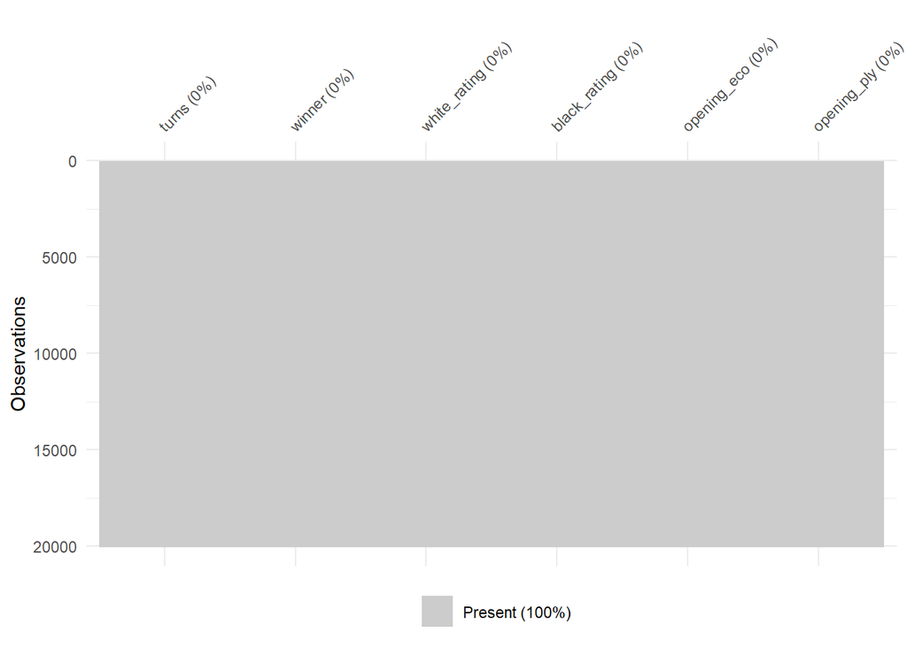

```r
vis_miss(data) #Check the amount of missing data
```

These different tables, graphs, and information tells us a lot about our data. The first table shows the first 6 rows of our data frame which has all the predictors we want for the remainder of the project. The second piece of information tells us that we have 20,058 observations to use for our training and testing sets. Finally, the last visual shows we have 0 missing data which is great as we will not need to take that factor into consideration later.

In this data set, we will be using 5 predictors:

- `turns`: Amount of turns in the entire match
- `white_rating`: The skill rating of the user playing with the white pieces
- `black_rating`: The skill rating of the user playing with the black pieces
- `opening_eco`: The 1 letter code that represents different categories of chess openings in the Encyclopaedia of Chess Openings (ECO). A is Flank Openings, B is Semi-Open Games, C is Open Games, D is Closed Games, and E is Indian defenses.
- `opening_ply`: Amount of turns the opening takes

## Visualizing the Data

We can see the data through a correlation heat map which will help us understand the predictors’ relationship with each other.

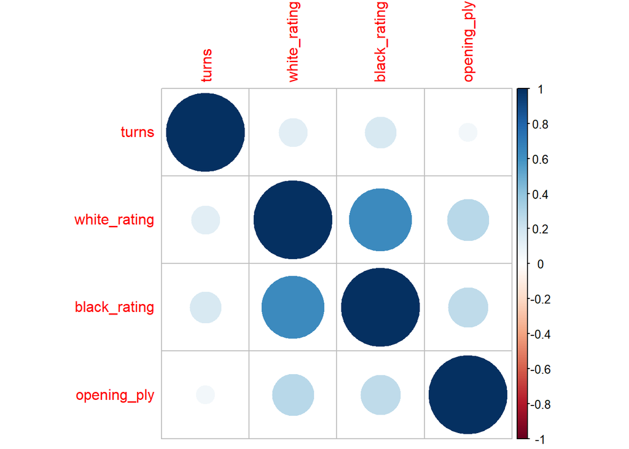

```r
data %>%
  select(where(is.numeric)) %>%
  cor() %>%
  corrplot()
```

Now we can look at different visualization plots to see how the predictors and outcome variables look.

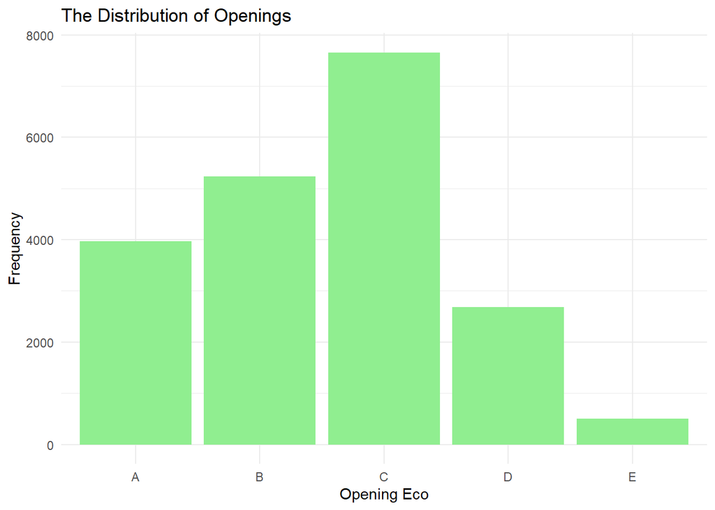

```r
ggplot(data, aes(x = opening_eco)) +
  geom_bar(fill = "lightgreen") +
  labs(title = "The Distribution of Openings", x = "Opening Eco", y = "Frequency") +
  theme_minimal()
```

As we can see the Open Game openings (C) are the most used with the Indian defenses (E) being the least used.

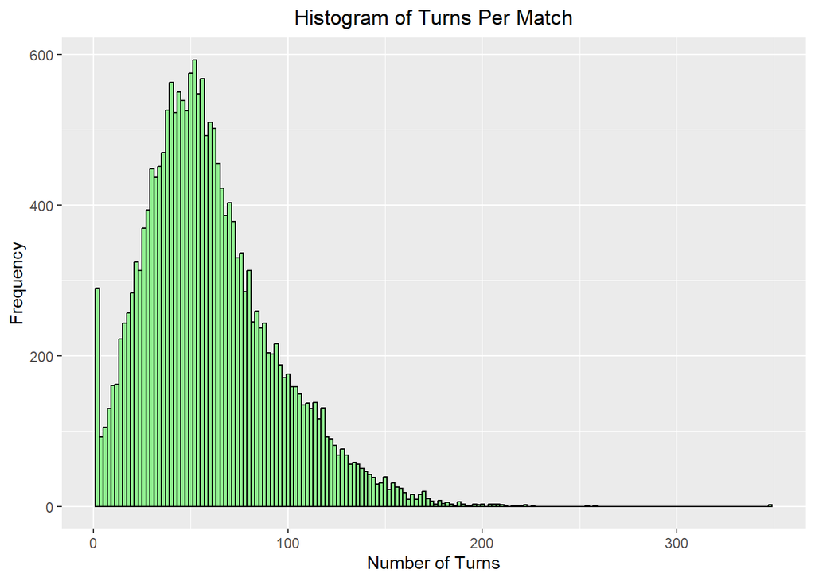

```r
ggplot(data = data, aes(x = turns)) +
  geom_histogram(binwidth = 2, fill="lightgreen", color="black") +
  labs(title = "Histogram of Turns Per Match", x = "Number of Turns", y = "Frequency") +
  theme(plot.title = element_text(hjust = 0.5))
```

This shows the amount of turns a game takes. There seems to be a high volume of games around 50 turns.

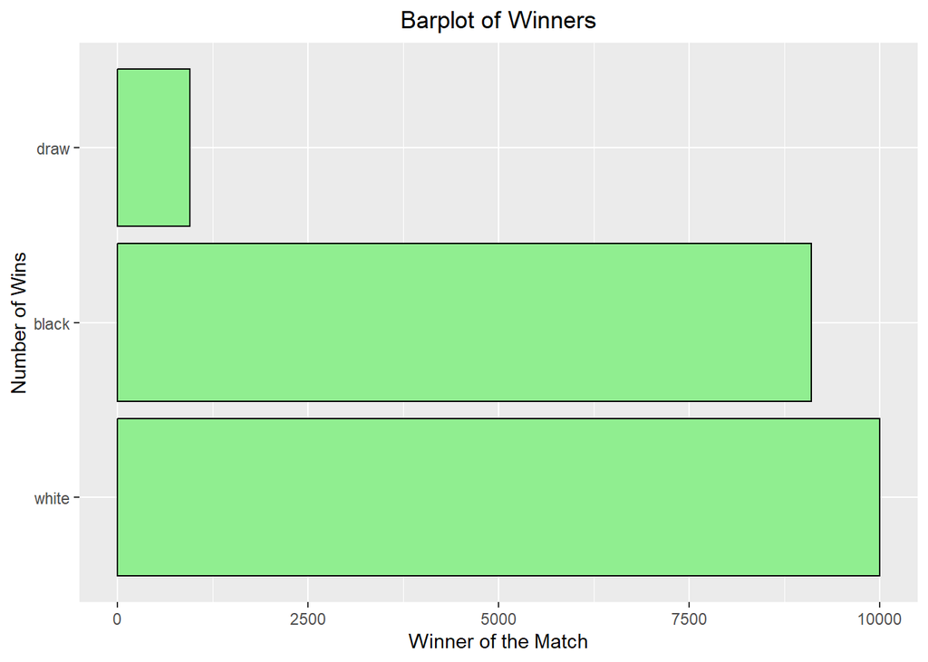

```r
ggplot(data = data, aes(y = fct_infreq(winner))) +
  geom_bar(fill = "lightgreen", color = "black") +
  labs(title = "Barplot of Winners", x = "Winner of the Match", y = "Number of Wins") +
  theme(plot.title = element_text(hjust = 0.5))
```

This is the outcome variable that shows the winners of the games. We can see that white wins slightly more than black on average.

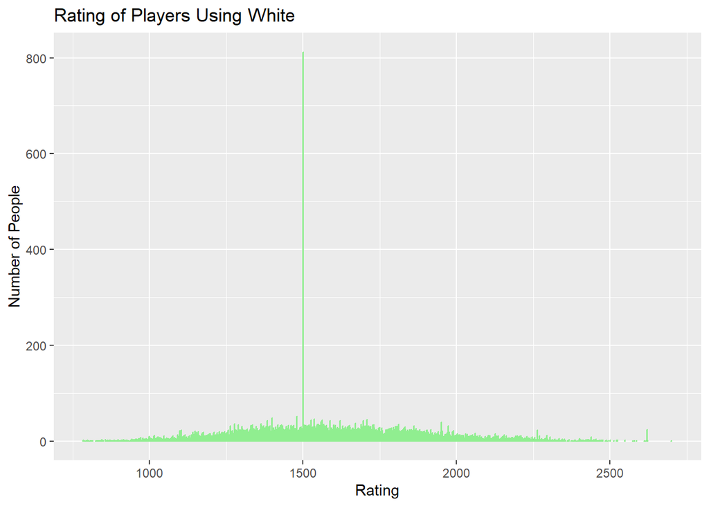

```r
ggplot(data = data, aes(white_rating)) +
  geom_bar(color = "lightgreen") +
  labs(x = "Rating", y = "Number of People", title = "Rating of Players Using White")
```

This shows what the rating of the players using white which are a wide range with a very high amount of players being around the 1500 rating.

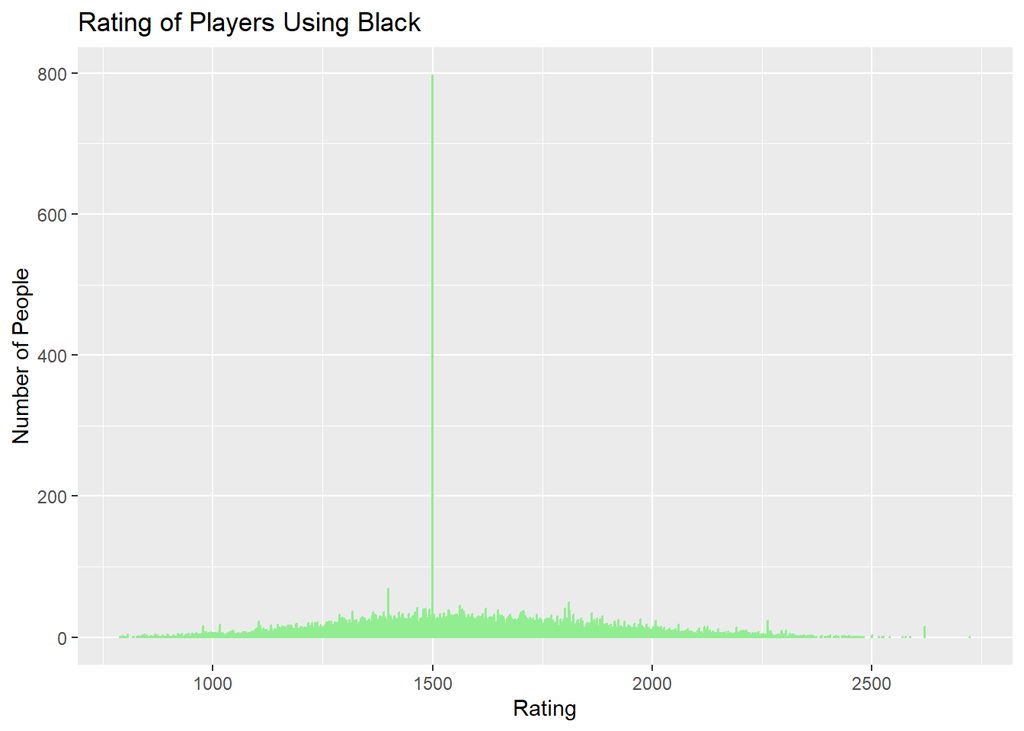

```r
ggplot(data = data, aes(black_rating)) +
  geom_bar(color = "lightgreen") +
  labs(x = "Rating", y = "Number of People", title = "Rating of Players Using Black")
```

Similar to the previous graph, this shows what the rating of the players using black. This has a wide range rating and a high amount of players being around the 1500 rating.

# Modeling the Data

Now we get into actually modeling the data. The first thing we need to do is split the data We will split our data into training and testing sets, set up and create our recipe, and establish cross-validation within our models.

## Splitting Data

The first thing we are going to be doing is splitting the data into training and testing sets. We start with a random seed to ensure the split is the same every time. We then need to choose a proportional split for the training and testing data which we will use 80/20 respectively. The reason we are using 80/20 is because there are a lot of observations we can train our model with.

```r
set.seed(3456)

chess_split <- initial_split(data, strata = winner, prop = 0.8)

chess_train <- training(chess_split)
chess_test <- testing(chess_split)
```

## Creating the Recipe

Now we craft our recipe by bringing together our predictors and our response variable which we will use for all the models. The recipe is shown below.

```r
chess_recipe <- recipe(winner ~ turns + white_rating + black_rating + opening_eco + opening_ply, chess_train) %>%
  step_dummy(all_nominal_predictors()) %>%
  step_center(all_predictors()) %>%
  step_scale(all_predictors())

chess_recipe %>%
  prep() %>%
  bake(new_data = chess_train)
```

[output not shown]

## K-Fold Cross Validation

We perform stratified cross validation stratifying over opening_eco using 5 folds.

```r
chess_folds <- vfold_cv(chess_train, v = 5, strata = opening_eco)
```

## Model Building

Now we build our model using four different machine learning techniques on our recipe. The tuning of the models can take multiple hours so instead we run the model, save them, and then load them for future uses. Using roc_auc as the metric for performance, we can see which model works best for our data. For three of our models, we tune the parameters to optimize the results. Our knn model gets tuned to find which neighbor value works best. For elastic net logistic regression, we tune both mixture and penalty. Tuning mixture will help us find which balance between lasso and ridge works best. Tuning the penalty helps us find which level of regularization is best. The last model that uses tuning is random forest. We tune mtry to see how many variables get tested at each split of a tree. We tune trees to get the best amount of trees in the random forest. Lastly, we tune min_n which checks the smallest amount of variables used to create a node of a tree.

```r
load("Chess-Fit.rda")
```

## Results

We now see how all the different models did with each parameter tuned.

```r
collect_metrics(knn_fit)
```

```
## # A tibble: 20 × 7
##    neighbors .metric  .estimator  mean     n std_err .config
##        <int> <chr>    <chr>      <dbl> <int>   <dbl> <chr>
##  1         1 accuracy multiclass 0.560     5 0.00237 Preprocessor1_Model01
##  2         1 roc_auc  hand_till  0.583     5 0.00359 Preprocessor1_Model01
##  3         2 accuracy multiclass 0.560     5 0.00237 Preprocessor1_Model02
##  4         2 roc_auc  hand_till  0.604     5 0.00317 Preprocessor1_Model02
##  5         3 accuracy multiclass 0.560     5 0.00237 Preprocessor1_Model03
##  6         3 roc_auc  hand_till  0.617     5 0.00416 Preprocessor1_Model03
##  7         4 accuracy multiclass 0.560     5 0.00234 Preprocessor1_Model04
##  8         4 roc_auc  hand_till  0.624     5 0.00300 Preprocessor1_Model04
##  9         5 accuracy multiclass 0.576     5 0.00151 Preprocessor1_Model05
## 10         5 roc_auc  hand_till  0.629     5 0.00327 Preprocessor1_Model05
## 11         6 accuracy multiclass 0.580     5 0.00164 Preprocessor1_Model06
## 12         6 roc_auc  hand_till  0.634     5 0.00336 Preprocessor1_Model06
## 13         7 accuracy multiclass 0.581     5 0.00213 Preprocessor1_Model07
## 14         7 roc_auc  hand_till  0.637     5 0.00450 Preprocessor1_Model07
## 15         8 accuracy multiclass 0.587     5 0.00308 Preprocessor1_Model08
## 16         8 roc_auc  hand_till  0.640     5 0.00473 Preprocessor1_Model08
## 17         9 accuracy multiclass 0.590     5 0.00245 Preprocessor1_Model09
## 18         9 roc_auc  hand_till  0.644     5 0.00551 Preprocessor1_Model09
## 19        10 accuracy multiclass 0.592     5 0.00210 Preprocessor1_Model10
## 20        10 roc_auc  hand_till  0.647     5 0.00537 Preprocessor1_Model10
```

```r
collect_metrics(log_fit)
```

```
## # A tibble: 2 × 6
##   .metric  .estimator  mean     n std_err .config
##   <chr>    <chr>      <dbl> <int>   <dbl> <chr>
## 1 accuracy multiclass 0.623     5 0.00233 Preprocessor1_Model1
## 2 roc_auc  hand_till  0.679     5 0.00231 Preprocessor1_Model1
```

```r
collect_metrics(enlr_fit)
```

```
## # A tibble: 200 × 8
##          penalty mixture .metric  .estimator  mean     n std_err .config
##            <dbl>   <dbl> <chr>    <chr>      <dbl> <int>   <dbl> <chr>
##  1 0.0000000001        0 accuracy multiclass 0.622     5 0.00205 Preprocessor1_…
##  2 0.0000000001        0 roc_auc  hand_till  0.679     5 0.00233 Preprocessor1_…
##  3 0.00000000129       0 accuracy multiclass 0.622     5 0.00205 Preprocessor1_…
##  4 0.00000000129       0 roc_auc  hand_till  0.679     5 0.00233 Preprocessor1_…
##  5 0.0000000167        0 accuracy multiclass 0.622     5 0.00205 Preprocessor1_…
##  6 0.0000000167        0 roc_auc  hand_till  0.679     5 0.00233 Preprocessor1_…
##  7 0.000000215         0 accuracy multiclass 0.622     5 0.00205 Preprocessor1_…
##  8 0.000000215         0 roc_auc  hand_till  0.679     5 0.00233 Preprocessor1_…
##  9 0.00000278          0 accuracy multiclass 0.622     5 0.00205 Preprocessor1_…
## 10 0.00000278          0 roc_auc  hand_till  0.679     5 0.00233 Preprocessor1_…
## # ℹ 190 more rows
```

```r
collect_metrics(rf_fit)
```

```
## # A tibble: 1,200 × 9
##     mtry trees min_n .metric  .estimator  mean     n std_err .config
##    <int> <int> <int> <chr>    <chr>      <dbl> <int>   <dbl> <chr>
##  1     1   200    10 accuracy multiclass 0.598     5 0.00460 Preprocessor1_Mode…
##  2     1   200    10 roc_auc  hand_till  0.690     5 0.00293 Preprocessor1_Mode…
##  3     2   200    10 accuracy multiclass 0.646     5 0.00329 Preprocessor1_Mode…
##  4     2   200    10 roc_auc  hand_till  0.717     5 0.00325 Preprocessor1_Mode…
##  5     3   200    10 accuracy multiclass 0.658     5 0.00145 Preprocessor1_Mode…
##  6     3   200    10 roc_auc  hand_till  0.724     5 0.00241 Preprocessor1_Mode…
##  7     4   200    10 accuracy multiclass 0.659     5 0.00205 Preprocessor1_Mode…
##  8     4   200    10 roc_auc  hand_till  0.728     5 0.00323 Preprocessor1_Mode…
##  9     5   200    10 accuracy multiclass 0.658     5 0.00350 Preprocessor1_Mode…
## 10     5   200    10 roc_auc  hand_till  0.724     5 0.00275 Preprocessor1_Mode…
## # ℹ 1,190 more rows
```

Below we see all the best tuned models using roc_auc as the metric.

```r
show_best(enlr_fit, n=1)
```

```
## # A tibble: 1 × 8
##   penalty mixture .metric .estimator  mean     n std_err .config
##     <dbl>   <dbl> <chr>   <chr>      <dbl> <int>   <dbl> <chr>
## 1 0.00599   0.778 roc_auc hand_till  0.679     5 0.00237 Preprocessor1_Model078
```

```r
show_best(knn_fit, n=1)
```

```
## # A tibble: 1 × 7
##   neighbors .metric .estimator  mean     n std_err .config
##       <int> <chr>   <chr>      <dbl> <int>   <dbl> <chr>
## 1        10 roc_auc hand_till  0.647     5 0.00537 Preprocessor1_Model10
```

```r
show_best(log_fit, n=1)
```

```
## # A tibble: 1 × 6
##   .metric .estimator  mean     n std_err .config
##   <chr>   <chr>      <dbl> <int>   <dbl> <chr>
## 1 roc_auc hand_till  0.679     5 0.00231 Preprocessor1_Model1
```

```r
show_best(rf_fit, n=1)
```

```
## # A tibble: 1 × 9
##    mtry trees min_n .metric .estimator  mean     n std_err .config
##   <int> <int> <int> <chr>   <chr>      <dbl> <int>   <dbl> <chr>
## 1     4   500    10 roc_auc hand_till  0.729     5 0.00190 Preprocessor1_Model0…
```

After seeing the best model is the random forest, we can now fit it to our testing data.

```r
best_rf <- select_best(rf_fit, metric = "roc_auc")

chess_final_wf <- finalize_workflow(rf_wflow, best_rf)
chess_final_fit <- fit(chess_final_wf, data=chess_train)

augment(chess_final_fit, new_data=chess_test) %>%
  roc_auc(winner, .pred_black:.pred_white)
```

```
## # A tibble: 1 × 3
##   .metric .estimator .estimate
##   <chr>   <chr>          <dbl>
## 1 roc_auc hand_till      0.748
```

After fitting our testing data, we can see that the roc auc value is 0.748 which is very good.

# Conclusion

By the end of it, we can take that the best model to predict the winner of a chess match based on the opening move is random forest. Our knn model was the forst out of all of them with a 0.647 roc auc value. The suprising thing is the enlr and log models were extremely close with the enlr model being 4.89e-05 better. We could improve this furthur by fitting more models onto the data to find if there is a better model that will achieve a higher accuracy. One model that comes to mind is boosted trees. A big takeaway for me during the project was trying to understand how different openings get classified and what they mean. Putting that into perspective really made it interesting to then see which opening can lead to wins depening on certain factors like rating.